# 95% Confidence Intervals

25/06/2023

## 95% Confidence Intervals

95 % confidence is a confidence that in the long-run 95 % of the CIs will include the true population value

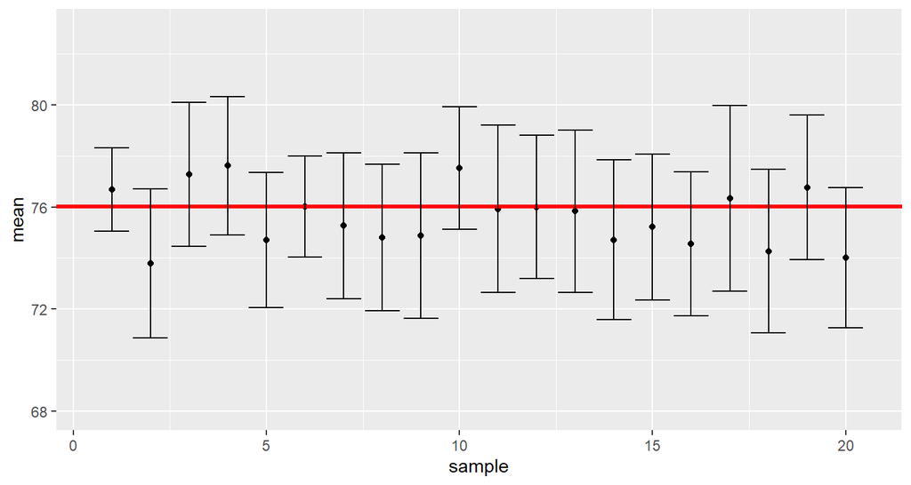

## How tall are our trees?

Today, we’re expressing all our love for the trees

```r
trees <- datasets::trees

head(trees)
```

```
##   Girth Height Volume
## 1   8.3     70   10.3
## 2   8.6     65   10.3
## 3   8.8     63   10.2
## 4  10.5     72   16.4
## 5  10.7     81   18.8
## 6  10.8     83   19.7
```

## Plotting tree height

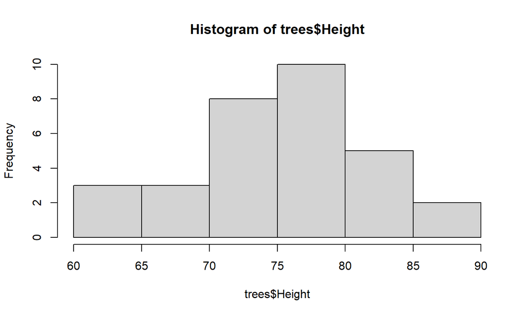

```r
hist(trees$Height)
```

## 95%CI of the mean

```r
mean(trees$Height)
```

```
## [1] 76
```

```r
sd(trees$Height)
```

```
## [1] 6.371813
```

```r
se = sd(trees$Height) / sqrt(nrow(trees))

se
```

```
## [1] 1.144411
```

## 95%CI of the mean

95%CI = point estimate +/- critical value*standard error

lower and upper critical values

```r
qnorm(c(.025,.975))
```

```
## [1] -1.959964  1.959964
```

```r
mean(trees$Height) + qnorm(.025) * se
```

```
## [1] 73.75699
```

```r
mean(trees$Height) + qnorm(.975) * se
```

```
## [1] 78.24301
```

## reporting

mean tree height was 76 metres, 95% CI [73.76, 78.24]

## Bootstraped Confidence Intervals

Some statistics are more complex, we may not have a closed-form equation

Bootstrapping involves taking lots of random samples from your data and calculating your statistic for each.

Then, you compile the whole distribution to extract the confidence intervals

In this example we’re interested in the mean tree BMI, for reasons

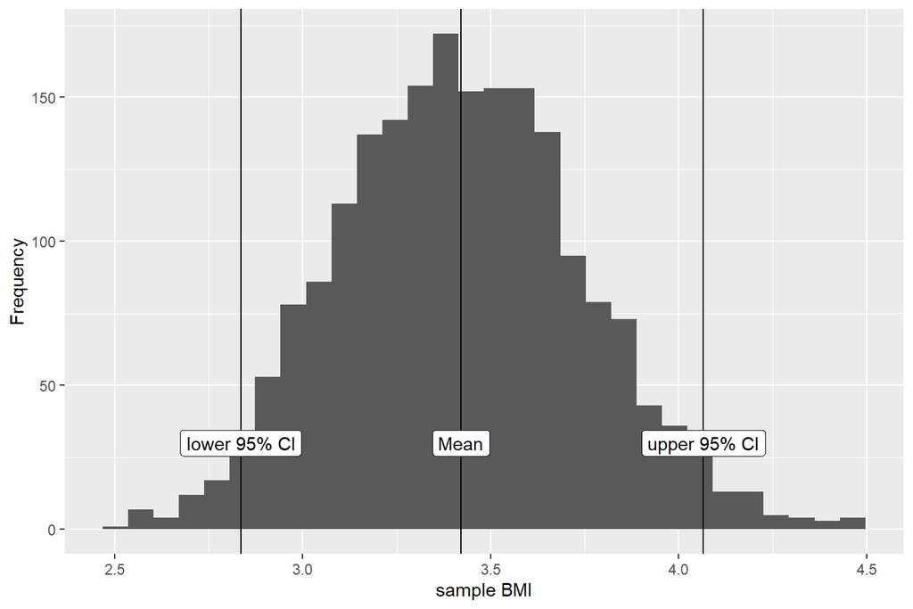

## Exercises

reminder, class code here: github.com/sdparsons/95CI_class

- calculate 95% CIs for tree girth (diameter) and volume
- calculate 90% CIs for tree height. How do the 90% and 95% CIs differ? discuss what this means?
- change the number of bootstrap re-samples, roughly how many re-samples do you think we need for precise CI estimates?

*bootstrapping exercises*

- calculate bootstrapped CIs for tree height
- plot the bootstrapped CIs (check github code for hints)